# Modeling_Ye

Elaine Ye

12/07/2021

```r
library(lubridate)
library(tidyverse)
library(xgboost)
library(Matrix)
library(caret)
library(ROSE)
load("bike_join.RData")
set.seed(260)
#only take 10% data for modeling due to limited computational power
bike_sub <- bike_join%>%
  #filter trip min within 120 min
  filter(trip_min < 120) %>%
  group_by(trip_date) %>% sample_frac(0.01) %>%
  filter(gender != 0)
#actual proportion of subscribers and customers
prop.table(table(bike_sub$user_type))
```

```
##
##   Customer Subscriber
##   0.152635   0.847365
```

```r
bike_mod <- bike_sub %>%
  ungroup() %>%
  #create day of week variable
  mutate(wday = ifelse(day_of_week %in% c("Mon", "Tue", "Wed", "Thu",
                                          "Fri"), 0, 1)) %>%
  mutate(wday = as.factor(wday)) %>%
   mutate(month = month(start_time)) %>%
    mutate(winter = ifelse(month %in% c(12,1,2), 1, 0))  %>%
  mutate(user_type = ifelse(user_type == "Subscriber", 1, 0)) %>%
  select(c(user_type, gender, age, median_household_income, distance_m, trip_min, suburb, winter))


set.seed(260)
options(na.action="na.pass")
#split train:test = 80%:20%
ind <- sample(2, nrow(bike_mod), replace = T, prob = c(0.8, 0.2))
train <- bike_mod[ind==1,]
over_train <- ovun.sample(user_type ~., data = train, method = "over")$data
test <- bike_mod %>% anti_join(train)
#one hot encode categorical variables for modeling
training <- model.matrix(~.+0, data = train[,-1])
over_training <- model.matrix(~.+0, data = over_train[,-1])
testing <- model.matrix(~.+0, data = test[,-1])
train.labels <- as.integer(train$user_type)
overtrain.labels <- as.integer(over_train$user_type)
test.labels <- as.integer(test$user_type)
```

### Original Data

```r
set.seed(260)
#create train.test matrix for XGboost model
xgb.train = xgb.DMatrix(data=training,label=train.labels)
xgb.test = xgb.DMatrix(data=testing,label=test.labels)
xgb.fit=xgb.train(
  booster="gbtree",
  eval_metric = "mlogloss",
  #step size shrinkage
  eta=0.05,
  #maximum depth of a tree
  max_depth =4,
  gamma = 0.01,
  #subsample ratio of the training to prevent overfitting
  subsample = 0.7,
  objective="binary:logistic",
  data=xgb.train,
  nrounds=100,
)

xgb.pred.prob <- predict(xgb.fit, testing, type = "response")
#use 0.5 cutoff
xgb.pred <- ifelse(xgb.pred.prob > 0.5, 1, 0)

confusionMatrix(as.factor(xgb.pred), as.factor(test.labels), positive = "1")
```

```
## Confusion Matrix and Statistics
##
##           Reference
## Prediction     0     1
##          0   682   377
##          1  4598 28824
##
##                Accuracy : 0.8557
##                  95% CI : (0.852, 0.8594)
##     No Information Rate : 0.8469
##     P-Value [Acc > NIR] : 2.23e-06
##
##                   Kappa : 0.1729
##
##  Mcnemar's Test P-Value : < 2.2e-16
##
##             Sensitivity : 0.9871
##             Specificity : 0.1292
##          Pos Pred Value : 0.8624
##          Neg Pred Value : 0.6440
##              Prevalence : 0.8469
##          Detection Rate : 0.8359
##    Detection Prevalence : 0.9693
##       Balanced Accuracy : 0.5581
##
##        'Positive' Class : 1
##
```

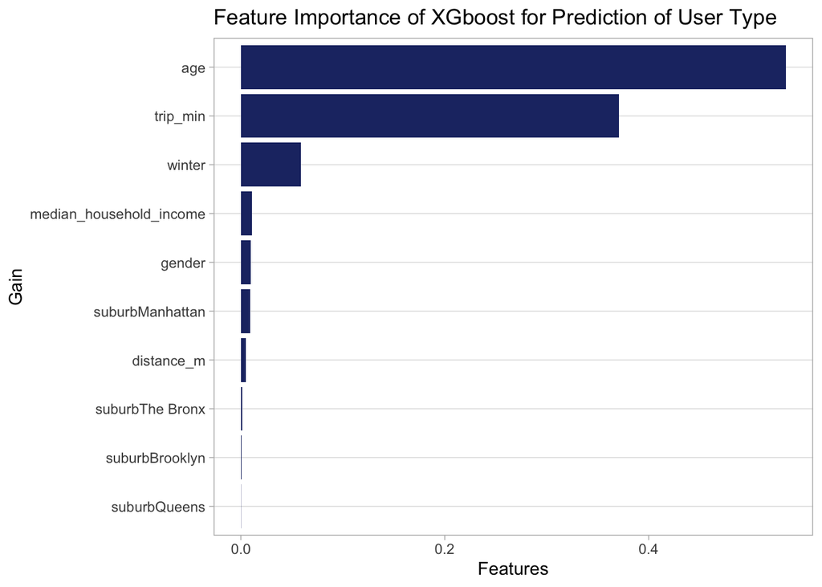

```r
imp <- xgb.importance(feature_names = colnames(training), model = xgb.fit)

pimp <- imp %>%
  mutate(Feature = fct_reorder(Feature, Gain)) %>%
  ggplot(data = ., aes(x=Gain, y = Feature)) +
  geom_col(fill = "#213272") +
  labs(title = "Feature Importance of XGboost for Prediction of User Type",
       x = "Features",
       y= "Gain") +
  theme_light() +
   theme(panel.grid.minor = element_blank(),
        panel.grid.major.x = element_blank())
pimp
```

The confusion matrix shows that the overall accuracy is 85.5%. The feature importance plot shows that the most predictive factors of user type are age, trip duration in minutes, and winter season.

#### Oversampled Data

```r
set.seed(260)
xgb.train_over = xgb.DMatrix(data=over_training,label=overtrain.labels)
xgb.fit_over =xgb.train(
  booster="gbtree",
  eval_metric = "mlogloss",
  #step size shrinkage
  eta=0.05,
  #maximum depth of a tree
  max_depth =4,
  gamma = 0.01,
  #subsample ratio of the training to prevent overfitting
  subsample = 0.7,
  objective="binary:logistic",
  data=xgb.train_over,
  nrounds=100,
)

xgb.pred.prob_over <- predict(xgb.fit_over, testing, type = "response")
#use 0.5 cutoff
xgb.pred_over <- ifelse(xgb.pred.prob_over > 0.5, 1, 0)

confusionMatrix(as.factor(xgb.pred_over), as.factor(test.labels), positive = "1")
```

```
## Confusion Matrix and Statistics
##
##           Reference
## Prediction     0     1
##          0  3993  9488
##          1  1287 19713
##
##                Accuracy : 0.6875
##                  95% CI : (0.6826, 0.6924)
##     No Information Rate : 0.8469
##     P-Value [Acc > NIR] : 1
##
##                   Kappa : 0.2636
##
##  Mcnemar's Test P-Value : <2e-16
##
##             Sensitivity : 0.6751
##             Specificity : 0.7562
##          Pos Pred Value : 0.9387
##          Neg Pred Value : 0.2962
##              Prevalence : 0.8469
##          Detection Rate : 0.5717
##    Detection Prevalence : 0.6090
##       Balanced Accuracy : 0.7157
##
##        'Positive' Class : 1
##
```

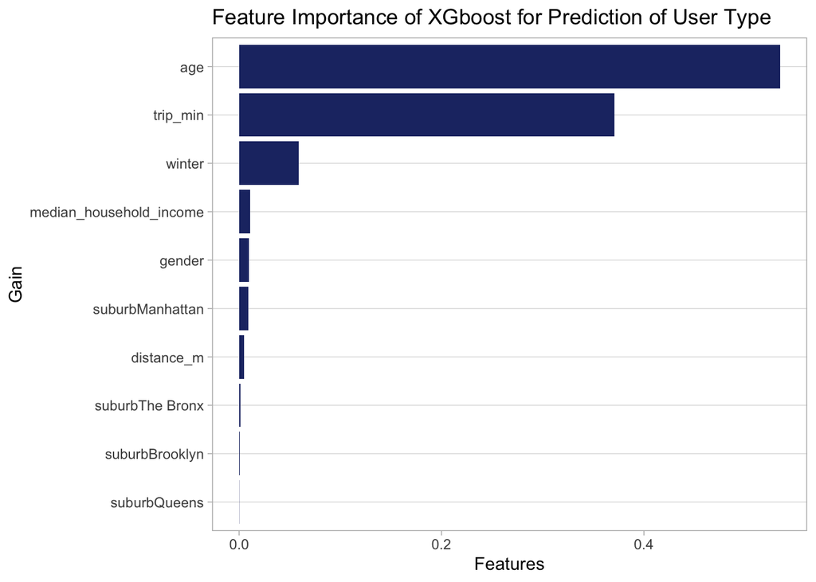

```r
imp2 <- xgb.importance(feature_names = colnames(over_training), model = xgb.fit_over)

pimp2 <- imp %>%
  mutate(Feature = fct_reorder(Feature, Gain)) %>%
  ggplot(data = ., aes(x=Gain, y = Feature)) +
  geom_col(fill = "#213272") +
  labs(title = "Feature Importance of XGboost for Prediction of User Type",
       x = "Features",
       y= "Gain") +
  theme_light() +
   theme(panel.grid.minor = element_blank(),
        panel.grid.major.x = element_blank())
pimp2
```

In this model, the accuracy is 69%, which becomes lower. The most important features are still age, trip duration in minutes, and winter. The sensitivity and specificity becomes more balanced, with sensitivity being 67.5% and specificity being 75.6%.

```r
library(pROC)
train_roc <- roc(test.labels,xgb.pred.prob)
train_roc_over <- roc(test.labels,xgb.pred.prob_over)
```

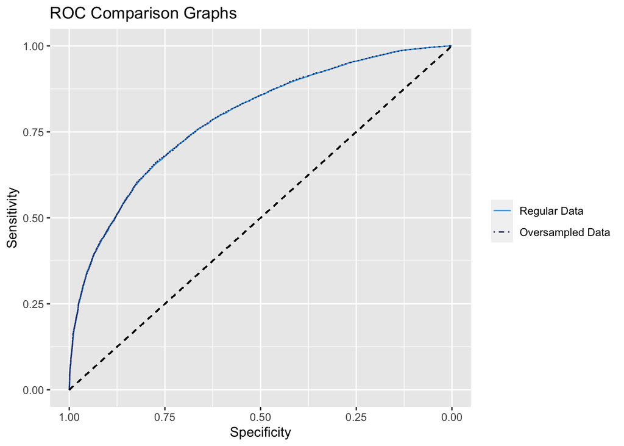

```r
ggroc(list("Regular Data" = train_roc,
           "Oversampled Data" = train_roc_over), legacy.axis = TRUE, aes = c("linetype", "color")) +
  labs(title = "ROC Comparison Graphs",
       x = "Specificity",
       y = "Sensitivity") +
  scale_color_manual(values = c("Regular Data" = "#36A3E2", "Oversampled Data" =  "#213272")
    ,labels = c("Regular Data","Oversampled Data"))  +
  scale_linetype_manual(
                         values = c("solid",  "dotdash")) +
  theme(legend.title = element_blank()) +
  geom_segment(aes(x = 1, xend = 0, y = 0, yend = 1), color = "black", linetype = "dashed")
```

```r
auc(train_roc)
```

```
## Area under the curve: 0.7884
```

```r
auc(train_roc_over)
```

```
## Area under the curve: 0.7888
```

1. While XGboost model already improves its model performance by building on weak learners, imbalanced class might still be a major problem in this dataset.
2. XGboost might overfit the model due to how it trians trees that are dependent on one and other and acheives low bias in the training set but might increase variance in the testing set. Also I did not use grid search to tune XGboost parameters here. Ways to improve the model include using cross-validation to balance bias and variance and using grid search to find the best parameters.
3. XGboost requires all categorical variable to be one hot encoded, which increases the dimension of the data and many columns may have mainly 0s.
4. The variables I picked might not be important to predict user type and we might want to consider other variables or truncate the number variables. In real life scenario, if a simpler model (like our logistic regression model in this case) achieves the task with better prediction and interpretability, we should definitely use the simpler model.
5. Since each row is a bike trip, the model is predicting whether the person rides the bike is a subscriber/ customer based on the features of a bike trip, rather than predicting whether a person is a subscriber/ customer given their user behaviors. So there might not be clearly different patterns among bike trips initiated by subscribers and customers to make a good prediction. Alternatively, if we have more data, we might want a dataset with each user as a row and use their behaviors to predict their user type.